# Session 1

A practical introduction to MCMC

Matt Denwood

2021-06-28

# Course Outline and Practicalities

## Overview

Date/time:

- 28th June to 1st July 2021
- 09.00 - 12.30 daily
- Use the same Zoom link all week!

Teachers:

- Matt Denwood (University Of Copenhagen)
- Nils Toft (IQinAbox)
- Søren Saxmose Nielsen (University Of Copenhagen)
- Maj Beldring Henningsen (University of Copenhagen)

## HARMONY

COST action CA18208: [https://harmony-net.eu/about/]

Goals are to encourage the use of latent class models/methods for:

- Diagnostic test evaluation
- Determination of true prevalence
- Certification of disease freedom

Period: October 2019 - October 2023

Contact: info@harmony-net.eu

## Practical information on the course

- All of the material is on the GitHub repository
  - We may tweak material as we go along
  - Remember to pull changes at the start of each day!
  - And click *refresh* in your browser! . . .
- Recordings of the sessions will put onto our website
  - The link will be sent out following the course
  - Feel free to share this with your colleagues
- Attendance registration is necessary for COST meetings
  - We will take care of this via Zoom

# Background

## Diagnostic test evaluation: with gold standard = simple!

```r
library("tidyverse")
se <- c(1, 0.6)
sp <- c(1, 0.9)
N <- 1000
prevalence <- 0.25

data <- tibble(Status = rbinom(N, 1, prevalence)) %>%
  mutate(Test1 = rbinom(N, 1, se[1]*Status + (1-sp[1])*(1-Status))) %>%
  # Which is the same as:
  mutate(Test1 = Status) %>%
  mutate(Test2 = rbinom(N, 1, se[2]*Status + (1-sp[2])*(1-Status)))

(twoXtwo <- with(data, table(Status, Test2)))
##       Test2
## Status   0   1
##      0 656  68
##      1 127 149
```

```r
(sensitivity <- twoXtwo[2,2] / sum(twoXtwo[2,1:2]))
## [1] 0.5398551
(specificity <- twoXtwo[1,1] / sum(twoXtwo[1,1:2]))
## [1] 0.9060773
```

## Diagnostic test evaluation: no gold standard

Now we have both values of sensitivity and specificity <1…

```r
se <- c(0.9, 0.6)
sp <- c(0.95, 0.9)
N <- 1000
prevalence <- 0.25

data <- tibble(Status = rbinom(N, 1, prevalence)) %>%
  mutate(Test1 = rbinom(N, 1, se[1]*Status + (1-sp[1])*(1-Status))) %>%
  mutate(Test2 = rbinom(N, 1, se[2]*Status + (1-sp[2])*(1-Status)))

with(data, table(Status, Test1))
##       Test1
## Status   0   1
##      0 691  35
##      1  32 242
with(data, table(Status, Test2))
##       Test2
## Status   0   1
##      0 667  59
##      1 104 170
```

In real life we don’t know what `Status` is…

```r
(twoXtwo <- with(data, table(Test1, Test2)))
##      Test2
## Test1   0   1
##     0 646  77
##     1 125 152
(sensitivity_1 <- twoXtwo[2,2] / sum(twoXtwo[1:2,2]))
## [1] 0.6637555
(sensitivity_2 <- twoXtwo[2,2] / sum(twoXtwo[2,1:2]))
## [1] 0.5487365
(specificity_1 <- twoXtwo[1,1] / sum(twoXtwo[1:2,1]))
## [1] 0.8378729
(specificity_2 <- twoXtwo[1,1] / sum(twoXtwo[1,1:2]))
## [1] 0.8934993
```

So we will *always* under-estimate the Se and Sp of both tests!

## The solution

- We need to assess the sensitivity and specificity of both tests against the true (but unknown) `Status` of each individual
- This unknown `Status` is called the `latent class`
  - Therefore we need to run a `latent class model` …
- How can we implement a latent class model?
  - Frequentist statistical methods:
    - possible, but difficult
  - Bayesian statistical methods:
    - easier and much more commonly done!

## Learning outcomes

By the end of the course you should be able to:

- Understand what a latent class model is, and how they can be used for diagnostic test evaluation
- Run basic latent class models using R and JAGS for real-world problems
- Interpret the results
- Understand the nuances and complexities associated with these types of analysis and the interpretation of the `latent class`

# Revision

## Bayes Rule

Bayes’ theorem is at the heart of Bayesian statistics:

$$P(\theta|Y) = \frac{P(\theta)\times P(Y|\theta)}{P(Y)}$$

Where: $\theta$ is our parameter value(s);

$Y$ is the data that we have observed;

$P(\theta|Y)$ is the posterior probability of the parameter value(s);

$P(\theta)$ is the prior probability of the parameters;

$P(Y|\theta)$ is the likelihood of the data given the parameters value(s);

$P(Y)$ is the probability of the data, integrated over parameter space.

- In practice we usually work with the following:

$$P(\theta|Y) \propto P(\theta)\times P(Y|\theta)$$

- Our Bayesian posterior is therefore always a combination of the likelihood of the data, and the parameter priors
- But for more complex models the distinction between what is ‘data’ and ‘parameters’ can get blurred!

## MCMC

- A way of obtaining a numerical approximation of the posterior
- Highly flexible
- Not inherently Bayesian but most widely used in this context
- Assessing convergence is essential, otherwise we may not be summarising the true posterior
- Our chains are correlated so we need to consider the effective sample size

## Bayesian MCMC vs Frequentist ML

Advantages:

- Very flexible modelling framework
- More natural interpretation of confidence intervals (credible intervals)
- Ability to incorporate prior information

Disadvantages:

- More computationally intensive
- More emphasis on the practictioner to ensure the output is reliable
- Requirement to incorporate prior information

## Everyone up to speed?

Any questions so far?

Anything unclear?

# Session 1: A practical introduction to MCMC

## MCMC in Practice

- We can write a Metropolis algorithm ourselves, but this is complex and inefficient
- There are a number of general purpose langauages that allow us to define the problem and leave the details to the software:
  - WinBUGS/OpenBUGS
    - Bayesian inference Using Gibbs Sampling
  - JAGS
    - Just another Gibbs Sampler
  - Stan
    - Named in honour of Stanislaw Ulam, pioneer of the Monte Carlo method

## JAGS

- JAGS uses the BUGS language
  - This is a declarative (non-procedural) language
  - The order of statements does not matter
  - The compiler converts our model syntax into an MCMC algorithm with appropriately defined likelihood and prior
  - You can only define each variable once!!!
- Different ways to run JAGS from R:
  - rjags, runjags, R2jags, jagsUI
- See http://runjags.sourceforge.net/quickjags.html
  - This is also in the GitHub folder

A simple JAGS model might look like this:

```
model{
  # Likelihood part:
  Positives ~ dbinom(prevalence, N)

  # Prior part:
  prevalence ~ dbeta(1, 1)

  # Hooks for automatic integration with R:
  #data# Positives, N
  #monitor# prevalence
  #inits# prevalence
}
```

There are two model statements:

- The first:

```r
Positives ~ dbinom(prevalence, N)
```

states that the number of `Positive` test samples is Binomially distributed with probability parameter `prevalence` and total trials `N`

- The second:

```r
prevalence ~ dbeta(1,1)
```

states that our prior probability distribution for the parameter `prevalence` is Beta(1,1), which is the same as Uniform(0,1)

These are very similar to the likelihood and prior functions defined in the preparatory exercise (although this prior is less informative)

The other lines in this model:

```r
#data# Positives, N
#monitor# prevalence
#inits# prevalence
```

are automated hooks that are only used by runjags

Compared to our Metropolis algorithm, this JAGS model is:

- Eaiser to write and understand
- More efficient (lower autocorrelation)
- Faster to run

To run this model, copy/paste the code above into a new text file called “basicjags.txt” in the same folder as your current working directory. Then run:

```r
library('runjags')

# data to be retrieved by runjags
Positives <- 70
N <- 100

# initial values to be retrieved by runjags:
prevalence <- list(chain1=0.05, chain2=0.95)
```

```r
results <- run.jags('basicjags.txt', n.chains=2, burnin=5000, sample=10000)
```

First check the plots for convergence:

```r
plot(results)
```

Trace plots: the two chains should be stationary:

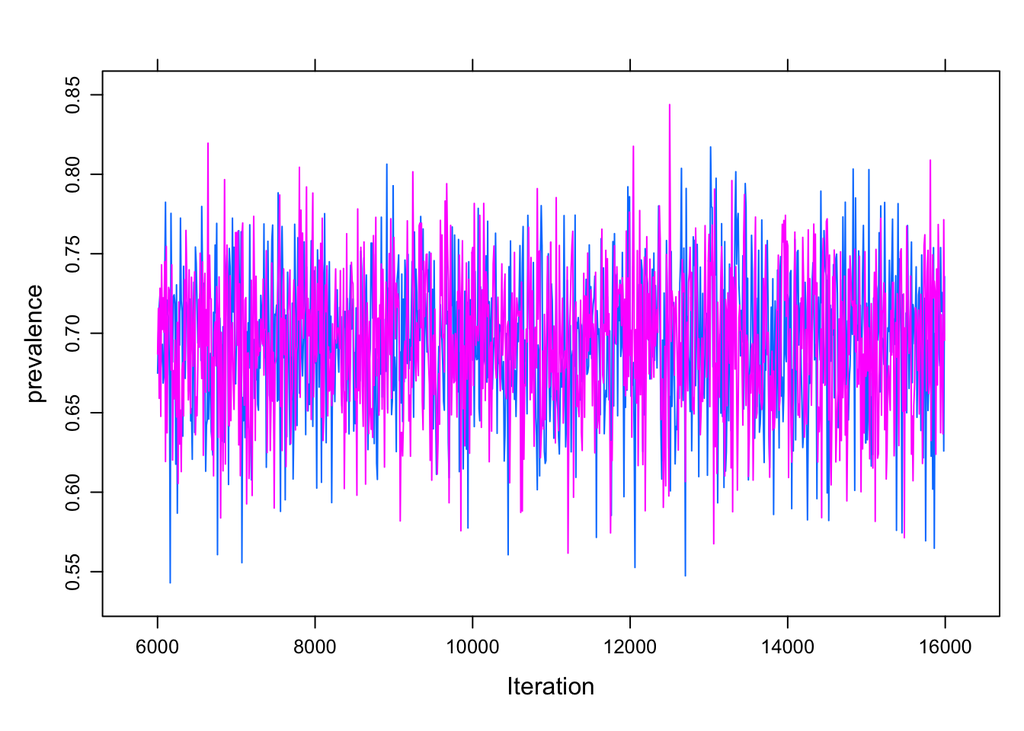

ECDF plots: the two chains should be very close to each other:

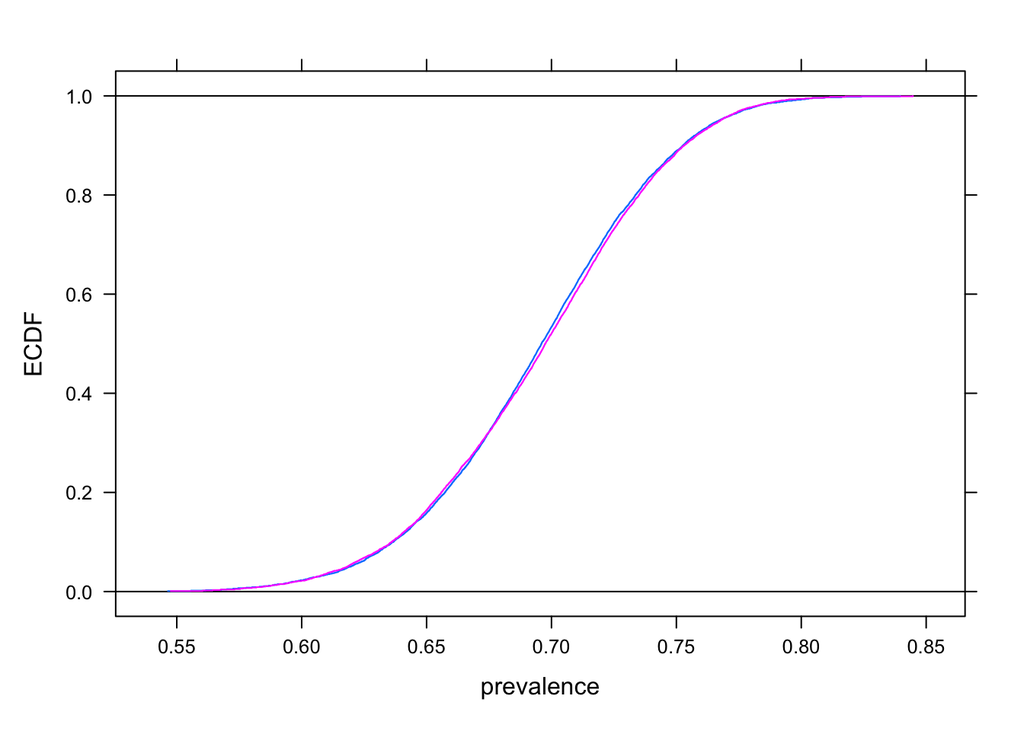

Histogram of the combined chains should appear smooth:

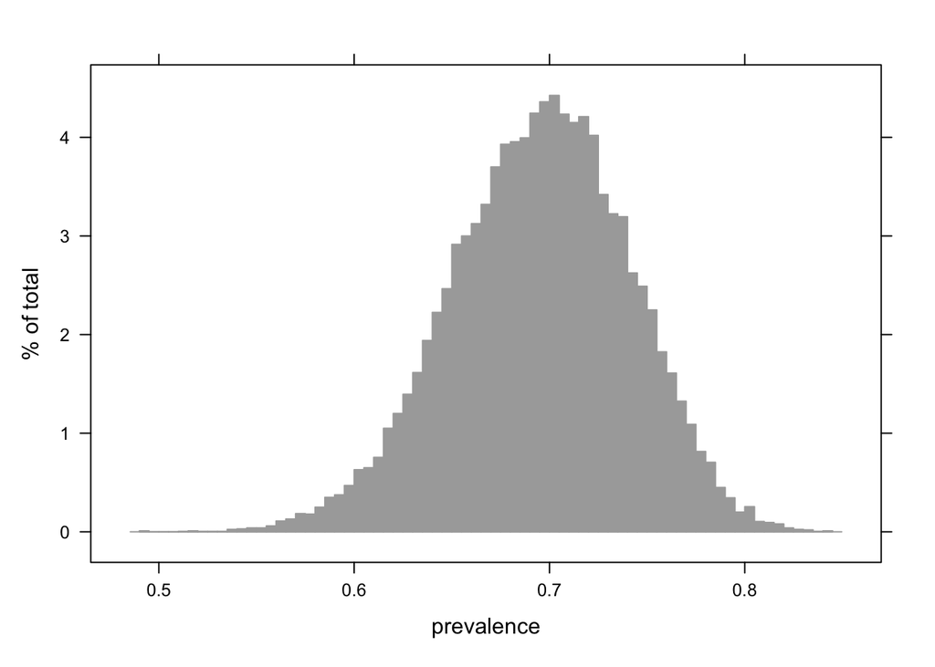

Autocorrelation plot tells you how well behaved the model is:

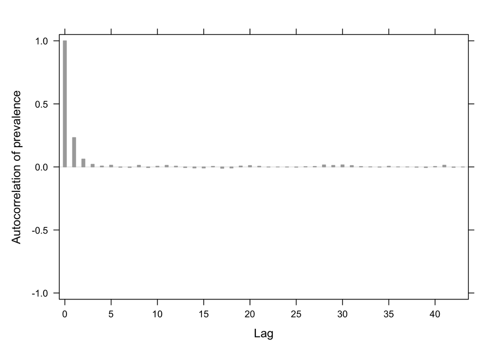

Note: for multiple parameters, use the ‘back’ button to cycle through plots!

Then check the effective sample size and Gelman-Rubin statistic:

```r
results
##
## JAGS model summary statistics from 20000 samples (chains = 2; adapt+burnin = 6000):
##
##            Lower95  Median Upper95    Mean       SD Mode      MCerr MC%ofSD
## prevalence 0.60724 0.69679 0.78319 0.69512 0.045452   -- 0.00041363     0.9
##
##            SSeff     AC.10 psrf
## prevalence 12075 0.0052717    1
##
## Total time taken: 0.2 seconds
```

Reminder: we want SSeff > 1000 and psrf < 1.05

## Introduction to practical sessions

Each practical session will consist of:

1. Some general/philosophical points to consider
2. One or more practical exercises for everyone to complete
3. One or more additional (optional) exercise for those that finish the main exercise early
4. A wrap-up discussion to reinforce the key messages

Consideration points are given in the PDF

The exercises (and solutions) are only in the HTML versions

- We have approximately 1 hour per practical session
  - 30-45 minutes for exercises, 15-30 minutes for discussion
- We will allocate you in pairs / threes to breakout rooms for the exercises (partly randomly, partly based on your institution)
  - If you need help please use the “Ask For Help” feature from your breakout room
  - Otherwise we will drop into the breakout rooms periodically to see how you are getting on!

# Practical Session 1

## Points to consider

1. What are the advantages and disadvantages of Bayesian MCMC relative to more standard frequentist likelihood-based methods?
2. `Identifiability` refers to the ability of a model to extract useful information from a dataset for a particular set of parameters. What 3 things affect whether or not a model/parameter will be identifiable?

The exercises can be found in Session_1.html!

## Exercise 1

Follow these steps to run the basic JAGS model given above:

- Create a new text file in RStudio by clicking on `File` then `New File` then `Text file`
- Copy the following model definition into this text file:

```
model{
  # Likelihood part:
  Positives ~ dbinom(prevalence, N)

  # Prior part:
  prevalence ~ dbeta(1, 1)

  # Hooks for automatic integration with R:
  #data# Positives, N
  #monitor# prevalence
  #inits# prevalence
}
```

- Save the file as `basicjags.txt` in a folder where you can find it again
- Set your R working directory to the same folder, by clicking on `Session` then `Set Working Directory` then `Choose Directory` and choosing the folder location
- Create a new R file in RStudio by clicking on `File` then `New File` then `R script`, and save the file as e.g. `Session 1 exercises.R` in the same folder
- Copy and paste the following R code into this R script file:

```r
library('runjags')

# data to be retrieved by runjags
Positives <- 70
N <- 100

# initial values to be retrieved by runjags:
prevalence <- list(chain1=0.05, chain2=0.95)

# run the model:
results <- run.jags('basicjags.txt', n.chains=2, burnin=5000, sample=10000)

# check convergence based on trace plots:
plot(results)

# check effective sample size and psrf, and then interpret results:
results
```

- Take your time to play around with this code and make sure that (1) it works, and (2) you know what is going on
- Change the initial values for prevalence to 0.5 in both chains. Does it make a difference to the output?
- Change the number of samples to e.g. 50000 or 100 - what difference does this make?
- Ask for help if you have problems!

### Solution 1

The result of running your R code should look like this (where lines starting with `##` show the output of running that line of code):

```r
# run the model:
results <- run.jags('basicjags.txt', n.chains=2, burnin=5000, sample=10000)
## Finished running the simulation
# Note: this is only commented out to save space in the exercise file!
# plot(results)

# check convergence and effective sample size, and then interpret results:
results
##
## JAGS model summary statistics from 20000 samples (chains = 2; adapt+burnin = 6000):
##
##            Lower95 Median Upper95    Mean       SD Mode      MCerr MC%ofSD
## prevalence  0.6082 0.6977 0.78508 0.69631 0.045115   -- 0.00041919     0.9
##
##            SSeff    AC.10    psrf
## prevalence 11583 0.010133 0.99997
##
## Total time taken: 0.4 seconds
```

Convergence is assessed in two ways: firstly from the trace plots, and secondly from the psrf (which is the Gelman-Rubin statistic). The effective sample size is SSeff. Once you are happy that the model has converged and has enough of a sample size, then you can interpret the results (typically median and 95% confidence interval estimates).

We can change the initial values like so:

```r
# initial values to be retrieved by runjags:
prevalence <- list(chain1=0.5, chain2=0.5)

# run the model:
results <- run.jags('basicjags.txt', n.chains=2, burnin=5000, sample=10000)
## Finished running the simulation
# Note: this is only commented out to save space in the exercise file!
# plot(results)
# check convergence and effective sample size, and then interpret results:
results
##
## JAGS model summary statistics from 20000 samples (chains = 2; adapt+burnin = 6000):
##
##            Lower95  Median Upper95    Mean       SD Mode      MCerr MC%ofSD
## prevalence 0.60742 0.69729 0.78499 0.69633 0.045479   -- 0.00040341     0.9
##
##            SSeff    AC.10   psrf
## prevalence 12710 0.014156 1.0003
##
## Total time taken: 0.1 seconds
```

This only makes a very small difference to the inference, because the model converges (and we remove burnin) in either case. The posteriors being independent of the initial values is a key assumption of using MCMC! But remember that there will always be a small difference because MCMC is an inherently random method. We just need to make sure that the effective sample size is high enough that this inherent randomness does not impact our inference (at least not when rounding to a sensible number of significant figures!).

Increasing the number of samples to 50000 improves the effective sample size, and therefore reduces the small random changes in the posterior inference, but also takes longer to run. Reducing the number of samples to 100 results in an effective sample size that is too small and therefore we get unreliable estimates that change every time the model is run!

## Exercise 2

We can fit the same model using frequentist maximum likelihood methods like this:

```r
Positives <- 70
N <- 100

# We can time how long this takes manually:
system.time({
  # The equivalent model to JAGS:
  freq_model <- glm(cbind(Positives, N-Positives) ~ 1, family=binomial)
})
##    user  system elapsed
##   0.003   0.000   0.002
# The intercept of the GLM is on the logit scale, so we need to take the inverse logit transform to get the prevalence:
plogis(coef(freq_model))
## (Intercept)
##         0.7
plogis(confint(freq_model))
## Waiting for profiling to be done...
##     2.5 %    97.5 %
## 0.6059070 0.7839748
```

Compare the results from the JAGS model and the frequentist model: - Are there any differences in the inference? - What about if you change the data to 7 positives out of 10? - Are there any practical differences between JAGS and standard GLM models?

Change the priors for the JAGS model from Beta(1,1) to Beta(20,1) - How does this affect the inference?

### Solution 2

The prevalence estimate and 95% CI from the frequentist method is 0.7 (0.61 - 0.78). The equivalent estimates from the Bayesian method are:

```r
summary(results)["prevalence", c("Median","Lower95","Upper95")]
##    Median   Lower95   Upper95
## 0.6972878 0.6074220 0.7849869
```

These are extremely close to each other in this case, although the same is not true with a smaller sample size:

```r
Positives <- 7
N <- 10

# Frequentist analysis:
freq_model <- glm(cbind(Positives, N-Positives) ~ 1, family=binomial)
plogis(coef(freq_model))
## (Intercept)
##         0.7
plogis(confint(freq_model))
## Waiting for profiling to be done...
##     2.5 %    97.5 %
## 0.3934574 0.9154480
# Bayesian analysis:
results <- run.jags('basicjags.txt', n.chains=2, burnin=5000, sample=10000)
## Finished running the simulation
# Note: this is only commented out to save space in the exercise file!
# plot(results)
results
##
## JAGS model summary statistics from 20000 samples (chains = 2; adapt+burnin = 6000):
##
##            Lower95 Median Upper95    Mean      SD Mode     MCerr MC%ofSD SSeff
## prevalence 0.41548 0.6777 0.90595 0.66797 0.13047   -- 0.0012191     0.9 11454
##
##                 AC.10   psrf
## prevalence -0.0064093 1.0002
##
## Total time taken: 0.1 seconds
```

Notice that the median estimate for the Bayesian model has shifted from 0.6972878 to 0.6777012, despite the maximum likelihood estimate remaining the same (0.7). This is due to the relatively larger impact of priors with smaller datasets. All Bayesian models *must* include priors - even when you don’t want to. We will return to this concept later today.

There is also a conceptual difference in the interpretation of the confidence intervals vs credible intervals - this is actually much easier when you are Bayesian!

The major downside of using MCMC is that it takes longer to run (glm runs in a few thousands of a second, whereas JAGS takes a few tenths of a second). The other downside is that you have to check convergence and effective sample size manually, which is not the case for using glm().

## Exercise 3

Up to now we have ignored issues of diagnostic test sensitivity and specificity. Usually, however, we do not have a perfect test, so we do not know how many are truly positive or truly negative, rather than just testing positive or negative. But we know that:

$$Prev_{obs} = (Prev_{true}\times Se) + ((1-Prev_{true})\times (1-Sp))$$
$$\implies Prev_{true} = \frac{Prev_{obs}-(1-Sp)}{Se-(1-Sp)}$$

[The second equation assumes that the observed prevalence and sensitivity are both higher than 1 minus the specificity!]

Using JAGS allows us to add this additional complexity to our models by including a parameter for true prevalence that is related to observed prevalence by sensitivity and specificity parameters:

```
model{
  # Likelihood part:
  Positives ~ dbinom(observed_prevalence, N)

  # Intermediate calculations:
  observed_prevalence <- sensitivity * prevalence + (1-specificity) * (1-prevalence)

  # Prior part:
  sensitivity ~ dbeta(1, 1)
  specificity ~ dbeta(1, 1)
  prevalence ~ dbeta(1, 1)

  # Hooks for automatic integration with R:
  #data# Positives, N
  #monitor# prevalence, sensitivity, specificity, observed_prevalence
  #inits# prevalence, sensitivity, specificity
}
```

Copy this model to “obsprevmodel.txt” and run it yourself in JAGS. Here is some additional R code that you will need:

```r
Positives <- 70
N <- 100

# initial values to be retrieved by runjags:
prevalence <- list(chain1=0.05, chain2=0.95)
sensitivity <- list(chain1=0.95, chain2=0.05)
specificity <- list(chain1=0.05, chain2=0.95)
```

- Make sure that the chains have converged and that your effective sample size is sufficient. Remember that now you have multiple monitored variables, so you need to cycle through the plots using the *back* and *forward* arrows on the plot window. The very last plot is a cross-correlation plot, which shows the pairwise correlation between the estimated parameter values. What do you notice about this?
- Look at the posteriors for the 4 parameters of interest. What do you notice about identifiability?
- Now set the sensitivity and specificity parameters to fixed values of 80% and 99% by commenting out the `sensitivity ~ dbeta(1, 1)` line and adding `sensitivity <- 0.8` in the model, and similarly commenting out the `specificity ~ dbeta(1, 1)` line and adding `specificity <- 0.99` in the model (you will also need to remove sensitivity and specificity from the #inits# line). What happens to identifiability now?

### Solution 3

```r
Positives <- 70
N <- 100

# initial values to be retrieved by runjags:
prevalence <- list(chain1=0.05, chain2=0.95)

# run the model:
results <- run.jags('obsprevmodel.txt', n.chains=2, burnin=5000, sample=10000)
## Finished running the simulation
# Note: this is only commented out to save space in the exercise file!
# plot(results)
# check convergence and effective sample size, and then interpret results:
results
##
## JAGS model summary statistics from 20000 samples (chains = 2; adapt+burnin = 6000):
##
##                         Lower95  Median Upper95    Mean       SD Mode
## prevalence             0.049995 0.48897 0.99037 0.49468   0.2784   --
## sensitivity             0.15632 0.69195 0.99959 0.64251  0.23018   --
## specificity         0.000076745 0.31063  0.8474 0.35877  0.23055   --
## observed_prevalence     0.60689 0.69475 0.78154 0.69348 0.044811   --
##
##                          MCerr MC%ofSD SSeff      AC.10   psrf
## prevalence           0.0059127     2.1  2217    0.13424 1.0003
## sensitivity          0.0057873     2.5  1582    0.20628 1.0012
## specificity           0.005566     2.4  1716    0.21352 1.0007
## observed_prevalence 0.00030423     0.7 21695 -0.0011098      1
##
## Total time taken: 0.5 seconds
```

The posterior for `observed_prevalence` is the same as for `prevalence` in the old model. But the posteriors for the new (true) `prevalence`, `sensitivity` and `specificity` are extremely wide! The model is only able to identify the `observed_prevalence`, and not the other three parameters. This is also reflected in the effective sample sizes. There is simply not enough information to disentangle them - persuade yourself this is true by considering the following possibilities:

- Is prevalence zero but the test is not very specific?
- Is prevalence 100% but the test is not very sensitive?
- Or anywhere in between?

The answer is that all are possible. But we can make prevalence identifiable by fixing sensitivity and specificity:

```
model{
  # Likelihood part:
  Positives ~ dbinom(observed_prevalence, N)

  # Intermediate calculations:
  observed_prevalence <- sensitivity * prevalence + (1-specificity) * (1-prevalence)

  # Prior part:
  #sensitivity ~ dbeta(1, 1)
  #specificity ~ dbeta(1, 1)
  sensitivity <- 0.8
  specificity <- 0.99
  prevalence ~ dbeta(1, 1)

  # Hooks for automatic integration with R:
  #data# Positives, N
  #monitor# prevalence, sensitivity, specificity, observed_prevalence
  #inits# prevalence
}
```

```r
results <- run.jags('obsprevmodel_fixsesp.txt', n.chains=2, burnin=5000, sample=10000)
## Note: The monitored variables 'sensitivity' and 'specificity' appear to
## be non-stochastic; they will not be included in the convergence
## diagnostic
## Finished running the simulation
results
##
## JAGS model summary statistics from 20000 samples (chains = 2; adapt+burnin = 6000):
##
##                     Lower95  Median Upper95    Mean       SD Mode      MCerr
## prevalence          0.76078 0.86979 0.97538 0.86818 0.055984   -- 0.00049945
## sensitivity             0.8     0.8     0.8     0.8        0   --         --
## specificity            0.99    0.99    0.99    0.99        0   --         --
## observed_prevalence 0.61102 0.69713 0.78055 0.69586 0.044227   -- 0.00039457
##
##                     MC%ofSD SSeff    AC.10   psrf
## prevalence              0.9 12564 -0.01036 1.0001
## sensitivity              --    --       --     --
## specificity              --    --       --     --
## observed_prevalence     0.9 12564 -0.01036 1.0002
##
## Total time taken: 0.3 seconds
```

Note that the true prevalence is estimated to be higher than the observed prevalence, because the test has a relatively low sensitivity.

If we don’t want to fix sensitivity/specificity at specific values (which is generally a bad idea!) then we can give them a strong prior instead. We will come back to this idea later!

## Optional Exercise A

- Change the number of chains to 1 and 4
  - Remember that you will also need to change the initial values
  - What affect does having different numbers of chains have?
- Try using the `run.jags` argument `method='parallel'` - what affect does this have?

### Solution A

The chains argument can be any positive integer, but you need to make sure that the number of initial values provided is consistent. For example:

```r
prevalence <- list(chain1=0.05)
sensitivity <- list(chain1=0.95)
specificity <- list(chain1=0.05)

results1 <- run.jags('obsprevmodel.txt', n.chains=1)
## Warning: Convergence cannot be assessed with only 1 chain
## Finished running the simulation
results1
##
## JAGS model summary statistics from 10000 samples (adapt+burnin = 5000):
##
##                        Lower95  Median Upper95    Mean       SD Mode      MCerr
## prevalence           0.0060642 0.49868 0.94543 0.49841   0.2793   --  0.0092178
## sensitivity            0.14297   0.685 0.99998 0.63276  0.23522   --  0.0085722
## specificity         0.00020673 0.30256 0.83721 0.35099  0.22815   --  0.0084584
## observed_prevalence    0.60666 0.69483 0.78067 0.69333 0.044509   -- 0.00043735
##
##                     MC%ofSD SSeff     AC.10 psrf
## prevalence              3.3   918   0.18361   --
## sensitivity             3.6   753   0.23011   --
## specificity             3.7   728   0.24832   --
## observed_prevalence       1 10357 0.0040663   --
##
## Total time taken: 0.3 seconds
prevalence <- list(chain1=0.05, chain2=0.4, chain3=0.6, chain4=0.95)
sensitivity <- list(chain1=0.95, chain2=0.75, chain3=0.25, chain4=0.05)
specificity <- list(chain1=0.05, chain2=0.25, chain3=0.75, chain2=0.95)
results4 <- run.jags('obsprevmodel.txt', n.chains=4)
## Finished running the simulation
results4
##
## JAGS model summary statistics from 40000 samples (chains = 4; adapt+burnin = 5000):
##
##                         Lower95  Median Upper95    Mean       SD Mode
## prevalence             0.014387 0.49378 0.95377  0.4973  0.28067   --
## sensitivity             0.15088 0.69152 0.99999 0.64261  0.23253   --
## specificity         0.000072567 0.30746 0.84569 0.35645    0.231   --
## observed_prevalence     0.60229 0.69488 0.77921 0.69354 0.045267   --
##
##                          MCerr MC%ofSD SSeff      AC.10   psrf
## prevalence           0.0043544     1.6  4155    0.14612  1.001
## sensitivity          0.0040876     1.8  3236    0.21746      1
## specificity          0.0041114     1.8  3157    0.21435 1.0002
## observed_prevalence 0.00023285     0.5 37794 -0.0091125 1.0001
##
## Total time taken: 1.1 seconds
```

There are two differences: firstly it is not possible to assess the psrf with only 1 chain (and it is harder to assess convergence generally), and secondly the effective sample size is higher with more chains as the samples are pooled (e.g. 10000 samples from 4 chains is 40000 samples). So more chains is better.

The downside is that more chains take longer to run. But we can offset this by parallelising:

```r
results4p <- run.jags('obsprevmodel.txt', n.chains=4, method='parallel')
## Warning: You attempted to start parallel chains without setting different PRNG
## for each chain, which is not recommended. Different .RNG.name values have been
## added to each set of initial values.
## Calling 4 simulations using the parallel method...
## All chains have finished
## Simulation complete.  Reading coda files...
## Coda files loaded successfully
## Finished running the simulation
results4p
##
## JAGS model summary statistics from 40000 samples (chains = 4; adapt+burnin = 5000):
##
##                        Lower95  Median Upper95    Mean       SD Mode     MCerr
## prevalence            0.045376 0.50295 0.98443 0.50201  0.27906   -- 0.0043922
## sensitivity            0.14925 0.68956  0.9996 0.64072  0.23025   -- 0.0040669
## specificity         9.8967e-07 0.30609 0.83999 0.35527  0.22947   --  0.004059
## observed_prevalence    0.60668 0.69452  0.7815 0.69342 0.044876   --  0.000228
##
##                     MC%ofSD SSeff      AC.10   psrf
## prevalence              1.6  4037    0.15353 1.0006
## sensitivity             1.8  3205    0.21826 1.0013
## specificity             1.8  3196    0.21386 1.0005
## observed_prevalence     0.5 38739 -0.0028591 1.0001
##
## Total time taken: 1.5 seconds
```

Each chain is run in parallel, so as long as you have at least as many processors as chains then you will reduce the run time. [Note: the run time is not reduced for this example because the model already runs very quickly and there is a small fixed overhead cost with parallelising chains, but for models that take longer to run you would see a benefit]

There are a large number of other options to runjags. Some highlights:

- The method can be parallel or background or bgparallel
- You can use extend.jags to continue running an existing model (e.g. to increase the sample size)
- You can use coda::as.mcmc.list to extract the underlying MCMC chains (for one more more partially matched variable name)
- You can use the summary() method to extract summary statistics (for one more more partially matched variable name)
  - See `?summary.runjags` and `?runjagsclass` for more information

## Optional excersie B

There are three other ways of writing this type of model. Using the simplest model as a template:

```
model{
  # Likelihood part:
  Positives ~ dbinom(prevalence, N)

  # Prior part:
  prevalence ~ dbeta(1, 1)

  # Hooks for automatic integration with R:
  #data# Positives, N
  #monitor# prevalence
  #inits# prevalence
}
```

We can replace:

```r
Positives ~ dbinom(prevalence, N)
```

with:

```r
for(i in 1:N){
  Result[i] ~ dbern(prevalence)
}
```

or:

```r
for(i in 1:N){
  NegativePositive[i] ~ dcat(prevalence[1:2])
}
observed_probabilities[2] <- prevalence
observed_probabilities[1] <- 1 - prevalence
```

or:

```r
Tally[1:2] ~ dmulti(observed_probabilities[1:2], N)

observed_probabilities[2] <- prevalence
observed_probabilities[1] <- 1 - prevalence
```

In each case the data is different: - `dbern` needs the response to be a vector of 0 and 1 reflecting test results for individuals, but uses the same probability as dbinom - `dcat` needs the response to be a vector of 1 and 2 reflecting the outcome (1=negative, 2=positive) of the test, and uses a pair of probabilities reflecting the probability of being negative and probability of being positive - `dmulti` needs the response to be a Tally of the total number of negative tests and positive tests, and uses the same pair of probabilities as `dcat`

Try to implement these models in JAGS, and see what difference it makes to (a) the model inference, and (b) the amount of time that the model takes to run.

What are the advantages and disadvantages of each approach?

### Solution B

Here is the model for dbern:

```
model{
  # Likelihood part:
  for(i in 1:N){
    Result[i] ~ dbern(prevalence)
  }

  # Prior part:
  prevalence ~ dbeta(1, 1)

  # Hooks for automatic integration with R:
  #data# Result, N
  #monitor# prevalence
  #inits# prevalence
}
```

And the necessary R code:

```r
Positives <- 70
N <- 100

# initial values to be retrieved by runjags:
prevalence <- list(chain1=0.05, chain2=0.95)
sensitivity <- list(chain1=0.95, chain2=0.05)
specificity <- list(chain1=0.05, chain2=0.95)

Result <- c(rep(0, N-Positives), rep(1, Positives))
stopifnot(sum(Result)==Positives)
dbern_results <- run.jags('dbernmodel.txt', n.chains=2)
## Finished running the simulation
```

Here is the model for dcat:

```
model{
  # Likelihood part:
  for(i in 1:N){
    NegativePositive[i] ~ dcat(observed_probabilities[1:2])
  }
  observed_probabilities[2] <- prevalence
  observed_probabilities[1] <- 1 - prevalence

  # Prior part:
  prevalence ~ dbeta(1, 1)

  # Hooks for automatic integration with R:
  #data# NegativePositive, N
  #monitor# prevalence
  #inits# prevalence
}
```

And the necessary R code:

```r
NegativePositive <- c(rep(1, N-Positives), rep(2, Positives))
dcat_results <- run.jags('dcatmodel.txt', n.chains=2)
## Finished running the simulation
```

And here is the model for dmulti:

```
model{
  # Likelihood part:
  Tally[1:2] ~ dmulti(observed_probabilities[1:2], N)

  observed_probabilities[2] <- prevalence
  observed_probabilities[1] <- 1 - prevalence

  # Prior part:
  prevalence ~ dbeta(1, 1)

  # Hooks for automatic integration with R:
  #data# Tally, N
  #monitor# prevalence
  #inits# prevalence
}
```

And the necessary R code:

```r
Tally <- c(N-Positives, Positives)
stopifnot(sum(Tally)==N)
dmulti_results <- run.jags('dmultimodel.txt', n.chains=2)
## Finished running the simulation
```

And the results from each of them:

```r
dbern_results
##
## JAGS model summary statistics from 20000 samples (chains = 2; adapt+burnin = 5000):
##
##            Lower95  Median Upper95    Mean       SD Mode      MCerr MC%ofSD
## prevalence 0.60781 0.69747 0.78192 0.69626 0.044937   -- 0.00031775     0.7
##
##            SSeff      AC.10 psrf
## prevalence 20000 -0.0090734    1
##
## Total time taken: 0.2 seconds
dcat_results
##
## JAGS model summary statistics from 20000 samples (chains = 2; adapt+burnin = 5000):
##
##            Lower95  Median Upper95    Mean       SD Mode      MCerr MC%ofSD
## prevalence 0.60673 0.69741  0.7813 0.69608 0.045173   -- 0.00040416     0.9
##
##            SSeff     AC.10    psrf
## prevalence 12492 -0.014599 0.99996
##
## Total time taken: 0.8 seconds
dmulti_results
##
## JAGS model summary statistics from 20000 samples (chains = 2; adapt+burnin = 5000):
##
##            Lower95  Median Upper95    Mean       SD Mode      MCerr MC%ofSD
## prevalence 0.60575 0.69686 0.78187 0.69573 0.045502   -- 0.00041048     0.9
##
##            SSeff       AC.10   psrf
## prevalence 12288 -0.00061119 1.0003
##
## Total time taken: 0.2 seconds
```

You should also note that the dbern version has a higher effective sample size. The reason for this is that JAGS can use a conjugate sampler in this case; this outside the scope of this course but you can read up on what this means [here](https://en.wikipedia.org/wiki/Conjugate_prior))

If you are really interested in what kind of sampler JAGS is using for each parameter, you can always find out:

```r
extract(dbern_results, "samplers")
##   Index.No             Sampler       Node
## 1        1 bugs::ConjugateBeta prevalence
extract(dcat_results, "samplers")
##   Index.No          Sampler                      Node
## 1        1 base::RealSlicer observed_probabilities[2]
extract(dmulti_results, "samplers")
##   Index.No          Sampler                      Node
## 1        1 base::RealSlicer observed_probabilities[2]
```

But the internal mechanisms of JAGS is well outside the scope of this course!

## Summary

- MCMC allows flexibility in models BUT requires more computational resource and user awareness
  - Convergence
  - Effective sample size
- Bayesian methods allow priors to be used BUT necessitate that priors are used
- Models are less likely to be identifiable if they:
  - Are more complex
  - Have less informative priors
  - Do not have sufficient data
- There is often a disparity between the model we would like to run and the model we can run given the data available